# Plots variants

Athena Tamayo Luisce

23/5/2021

```r
library(ggplot2)
library(dplyr)
```

Files with variants associated with monogenic diseases

```r
setwd("/home/athena/Escritorio/CCG/4toSemestre/GenoHumana/Proyecto")
data1 <- read.table("PathogenicVariants.variant_function", sep = "\t", header = FALSE)
data2 <- read.table("PathogenicVariantsInvalid.variant_function", sep = "\t", header = FALSE)
exons1 <- read.table("ExonicPathogenicVariants.variant_function", sep = "\t", header = FALSE)
exons2 <- read.table("ExonicPathogenicVariantsInvalid.variant_function", sep = "\t", header = FALSE)
```

Merge data1/data2 and exon1/exon2

```r
data <- left_join(data1, data2)
exons <- left_join(exons1, exons2)
colnames(data) <- c("location", "gene", "description")
head(data, 20)
```

```
##    location
## 1    exonic
## 2    exonic
## 3    exonic
## 4    exonic
## 5    exonic
## 6    exonic
## 7    exonic
## 8    exonic
## 9    exonic
## 10   exonic
## 11   exonic
## 12   exonic
## 13   exonic
## 14   exonic
```

[output cut: 48 more lines]

```r
dim(data)
```

```
## [1] 17582     3
```

```r
dim(exons)
```

```
## [1] 15755     4
```

Files with the loci associated with monogenic diseases

```r
setwd("/home/athena/Escritorio/CCG/4toSemestre/GenoHumana/Proyecto")
data1 <- read.table("./ANNOVAR_hg38_filtered/Monogenic3.variant_function", sep = "\t", header = FALSE)
data2 <- read.table("./ANNOVAR_hg38_invalid_filtered/Monogenic3_1.variant_function", sep = "\t", header = FALSE)
```

Merge data1/data2 and exon1/exon2

```r
loci <- left_join(data1, data2)
colnames(loci) <- c("location", "gene", "description")
```

```r
dim(loci)
```

```
## [1] 14358     3
```

```r
nrowLoci <- nrow(loci)
```

Plot the frequency of non coding and coding regions with variants and loci associated with monogenic diseases

```r
# create dataframe of variant frequencies
freq <- as.data.frame(table(data$location))
# add the percentages
freq$Perc <- round((freq$Freq)/sum(freq$Freq)*100, 2)

# create dataframe of the loci frequencies
freqLoci <- as.data.frame(table(loci$location))
# add the percentages
freqLoci$Perc <- round((freqLoci$Freq)/sum(freqLoci$Freq)*100, 2)
```

```r
# Get the frequency of the coding and non-coding regions with variants associated with monogenic
regions1 <- data.frame(region = c("coding", "non-coding"),
                      freq = c(sum(freq$Freq[c(1, 2)]),
                               sum(freq$Freq[c(3, 4, 5, 6, 7, 8, 9, 10, 11)])),
                      genomic = c("Variants", "Variants"))
regions1$perc <- round(regions1$freq/sum(freq$Freq)*100, 2)

# Get the frequency of the coding and non-coding regions with loci associated with monogenic
regions2 <- data.frame(region = c("coding", "non-coding"),
                      freq = c(sum(freqLoci$Freq[c(1, 2)]),
                               sum(freqLoci$Freq[c(3, 4, 5, 6, 7, 8, 9, 10, 11)])),
                      genomic = c("Loci", "Loci"))
regions2$perc <- round(regions2$freq/sum(freqLoci$Freq)*100, 2)
```

```r
# Merge both dataframes
regions <- rbind(regions1, regions2)
```

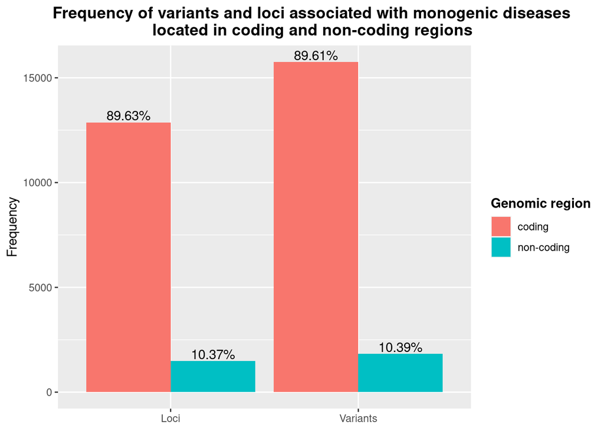

```r
ggplot(regions, aes(x = genomic, y = freq, fill = region)) +
  geom_bar(stat = "identity", position = position_dodge()) +
  theme(plot.title = element_text(face = "bold", hjust = 0.05),
        legend.title =  element_text(face = "bold")) +
  labs(title = "Frequency of variants and loci associated with monogenic diseases
                     located in coding and non-coding regions", x = NULL, y = "Frequency") +
  scale_fill_discrete(name = "Genomic region") +
  geom_text(aes(label = paste(perc, "%", sep = "")), vjust = -0.2, position = position_dodge(width = 0.9))
```

Plot the frequency of mutations associated with monogenic diseases located in different genomic regions.

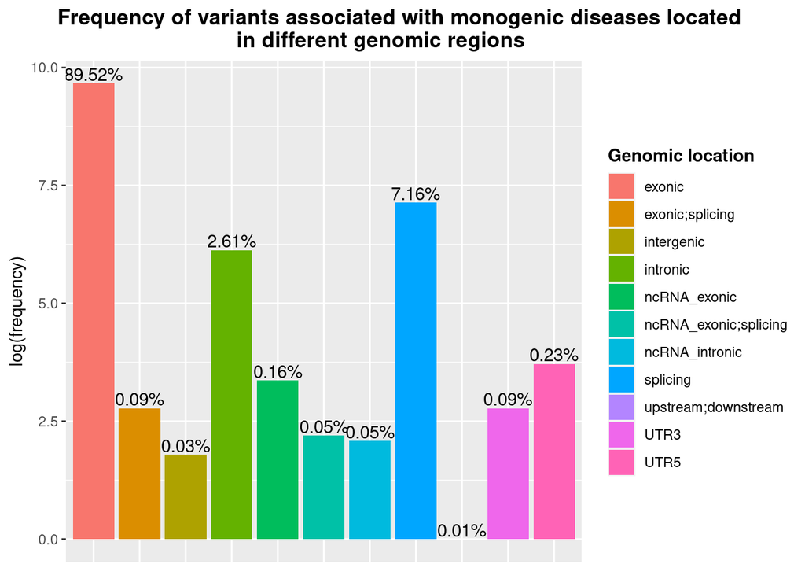

```r
ggplot(freq, aes(x = Var1, y = log(Freq), fill = Var1)) +
  geom_bar(stat = "identity") +
  theme(axis.ticks.x = element_blank(),
        axis.text.x=element_blank(),
        plot.title = element_text(face = "bold", hjust = 0.05),
        legend.title =  element_text(face = "bold")) +
  labs(title = "Frequency of variants associated with monogenic diseases located
                            in different genomic regions", x = NULL, y = "log(frequency)") +
  scale_fill_discrete(name = "Genomic location") +
  geom_text(aes(label = paste(Perc, "%", sep = "")), vjust = -0.2)
```

Label info: https://annovar.openbioinformatics.org/en/latest/user-guide/gene/

Plot the frequency of the types of the type of mutations associated with monogenic diseases in exons

```r
head(exons)
```

```
##      V1                V2
## 1 line1 nonsynonymous SNV
## 2 line2 nonsynonymous SNV
## 3 line3 nonsynonymous SNV
## 4 line4 nonsynonymous SNV
## 5 line5 nonsynonymous SNV
## 6 line6          stopgain
##                                                                                                                      V3
## 1                                    CLCN4:NM_001830:exon11:c.G1606A:p.V536M,CLCN4:NM_001256944:exon9:c.G1324A:p.V442M,
## 2                                   CLCN4:NM_001830:exon12:c.G2191C:p.G731R,CLCN4:NM_001256944:exon10:c.G1909C:p.G637R,
## 3                                                                                 CLCN4:NM_001830:exon4:c.G232A:p.G78S,
## 4                                       CLCN4:NM_001830:exon7:c.C661G:p.L221V,CLCN4:NM_001256944:exon5:c.C379G:p.L127V,
## 5 HCCS:NM_001171991:exon7:c.C649T:p.R217C,HCCS:NM_001122608:exon7:c.C649T:p.R217C,HCCS:NM_005333:exon7:c.C649T:p.R217C,
## 6 HCCS:NM_001171991:exon6:c.C589T:p.R197X,HCCS:NM_001122608:exon6:c.C589T:p.R197X,HCCS:NM_005333:exon6:c.C589T:p.R197X,
##                                                                                                V4
## 1 X 10213710 10213710 G A comments: rs1569231897, Mutation, X-linked dominant, 302910, pathogenic
## 2 X 10220876 10220876 G C comments: rs1569233549, Mutation, X-linked dominant, 302910, pathogenic
## 3 X 10187602 10187602 G A comments: rs1569226551, Mutation, X-linked dominant, 302910, pathogenic
## 4 X 10206463 10206463 C G comments: rs1569230006, Mutation, X-linked dominant, 302910, pathogenic
## 5  X 11121652 11121652 C T comments: rs121917889, Mutation, X-linked dominant, 300056, pathogenic
## 6  X 11120974 11120974 C T comments: rs121917888, Mutation, X-linked dominant, 300056, pathogenic
```

```r
mut <- as.data.frame(table(exons$V2))
mut$Perc <- round((mut$Freq)/sum(mut$Freq)*100, 2)
```

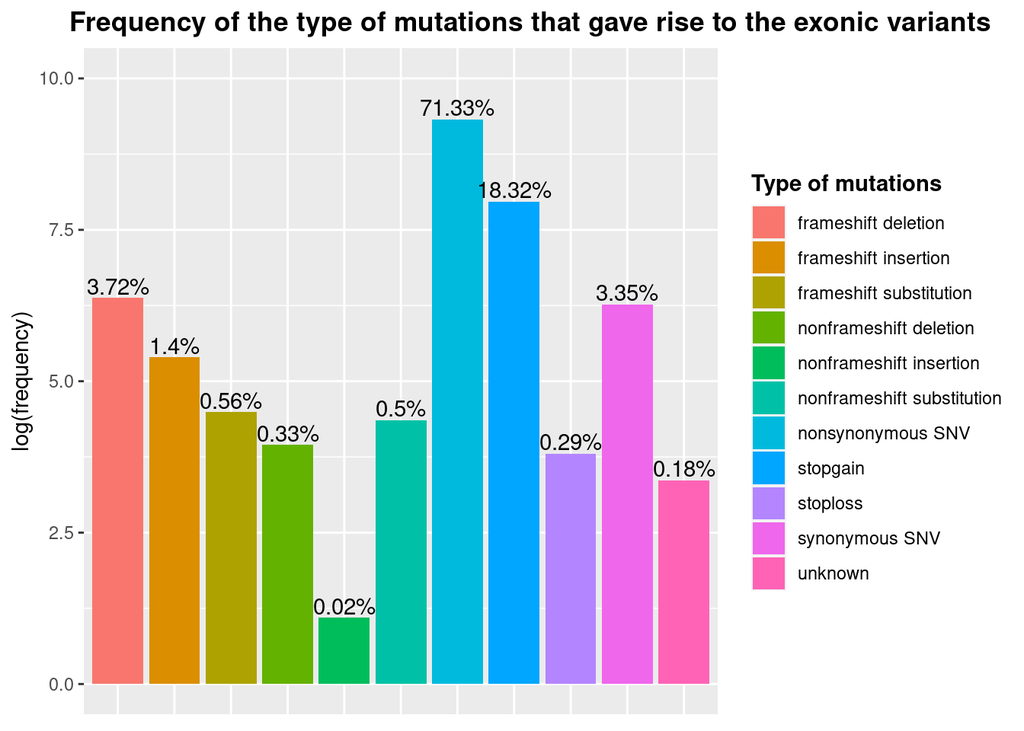

```r
ggplot(mut, aes(x = Var1, y = log(Freq), fill = Var1)) +
  geom_bar(stat = "identity") +
  theme(axis.ticks.x = element_blank(),
        axis.text.x=element_blank(),
        plot.title = element_text(face = "bold", hjust = 0.05),
        legend.title =  element_text(face = "bold")) +
  labs(title = "Frequency of the type of mutations that gave rise to the exonic variants",
       x = NULL, y = "log(frequency)") +
  scale_fill_discrete(name = "Type of mutations") +
  geom_text(aes(label = paste(Perc, "%", sep = "")), vjust = -0.2) +
  ylim(0, 10)
```

Split the description of the variants and loci

```r
elements <- strsplit(data$description, split = "[,]")
elemLoci <- strsplit(loci$description, split = "[,]")
```

Plot the type of inheritance of the variants and loci

```r
inheritance <- vector()
for (i in 1:15633){
  inheritance <- c(inheritance, elements[[i]][3])
}

inheritance <- as.data.frame(table(inheritance))
inheritance$Perc <- round((inheritance$Freq)/sum(inheritance$Freq)*100, 2)
inheritance$Genomic <- rep("Variants", 6)
```

```r
inhLoci <- vector()
for (i in 1:nrowLoci){
  inhLoci <- c(inhLoci, elemLoci[[i]][3])
}

inhLoci <- as.data.frame(table(inhLoci))
inhLoci$Perc <- round((inhLoci$Freq)/sum(inhLoci$Freq)*100, 2)
inhLoci$Genomic <- rep("Loci", 6)
colnames(inhLoci)[1] <- "inheritance"
```

```r
inheritance <- rbind(inheritance, inhLoci)
```

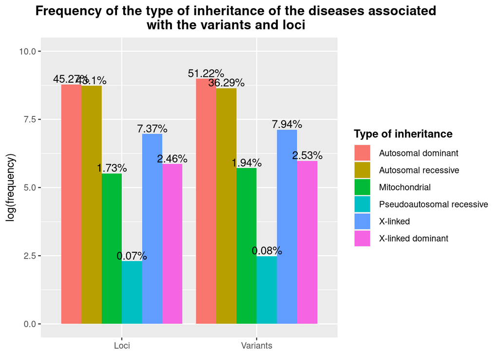

```r
ggplot(inheritance, aes(x = Genomic, y = log(Freq), fill = inheritance)) +
  geom_bar(stat = "identity", position=position_dodge()) +
  theme(plot.title = element_text(face = "bold", hjust = 0.05),
        legend.title =  element_text(face = "bold")) +
  labs(title = "Frequency of the type of inheritance of the diseases associated \n                            with the variants and loci",
       x = NULL, y = "log(frequency)") +
  scale_fill_discrete(name = "Type of inheritance") +
  geom_text(aes(label = paste(Perc, "%", sep = "")), vjust = -0.2,
            position = position_dodge(width = 0.9)) +
  ylim(0, 10)
```

```r
disease <- vector()
for (i in 1:15633){
  disease <- c(disease, elements[[i]][4])
}
```

```r
disease <- as.data.frame(table(disease))
```

```r
summary(disease$Freq)
```

```
##    Min. 1st Qu.  Median    Mean 3rd Qu.    Max.
##   1.000   2.000   4.000   5.422   7.000 173.000
```

```r
table(disease$Freq)
```

```
##
##   1   2   3   4   5   6   7   8   9  10  11  12  13  14  15  16  17  18  19  20
## 486 462 406 333 242 205 153 111  87  90  47  45  40  41  14  18  10  14  10   6
##  21  22  23  24  25  26  27  28  29  30  31  32  34  35  36  37  38  40  43  46
##   6   5   4   5   4   3   3   1   3   2   2   2   3   4   2   1   2   3   1   1
##  52  54  58  80 149 173
##   1   1   1   1   1   1
```